# 15th July

Anna Hutchinson

04/07/2019

### Investigating $\mu$

- I have found that our correction method struggles in high LD regions, which may be due to our estimate for $\mu$.
- Interestingly, in the T1D results there seems to be a negative correlation between corrected coverage value and $\mu$. This reflects the results of our simulations that in high powered scenarioes, our correction consistently estimates the corrected coverage to be too low.
- I re-run the simulations saving the 4 estimates for $\mu$ that we considered.
- These simulations are in PLOS/mus/

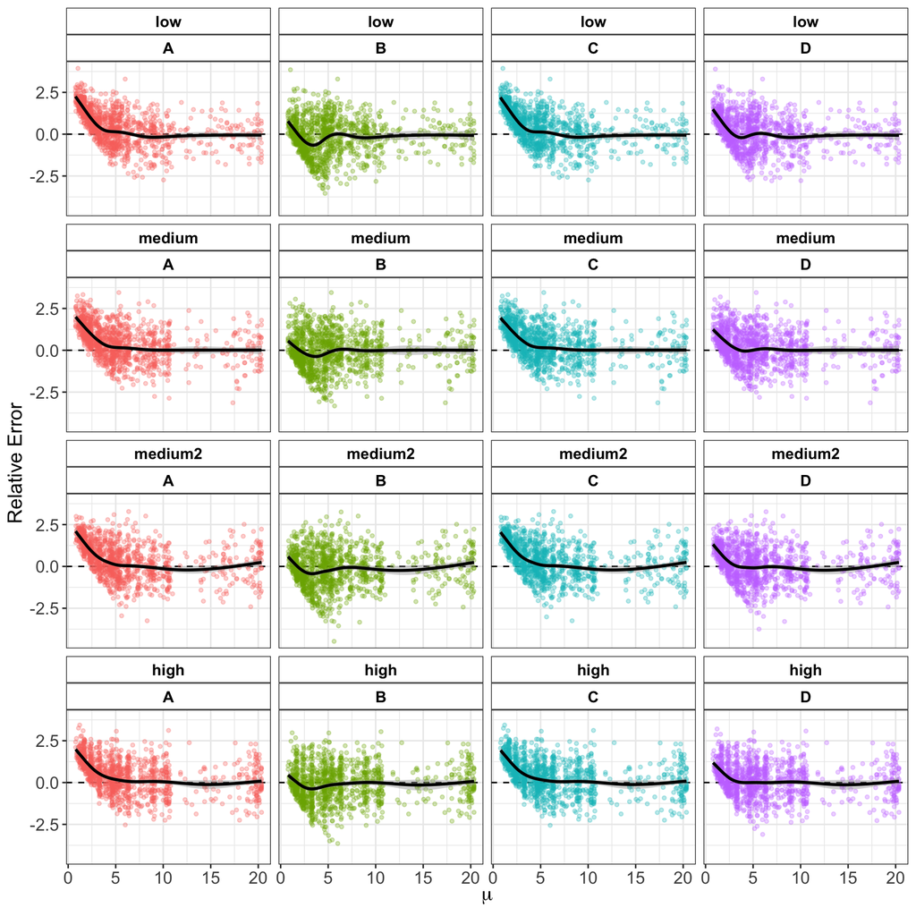

### Correlation between muhat and Corrected Coverage

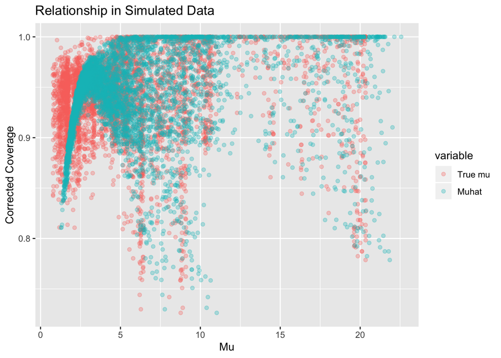

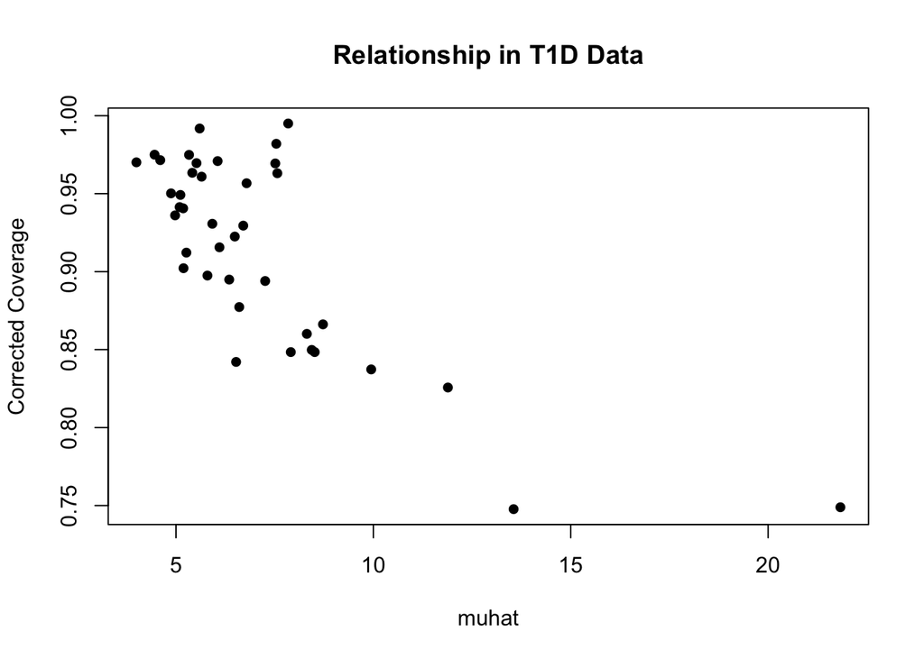

### Using Reference Panel

- In the real world setting, researchers have Z scores, MAFs and sample sizes from their study. They may then use a reference panel (such as the 1000 Genomes project) to get an estimate for the LD patterns between their SNPs.
- To see how our method performs in this setting, I use UK10K data to simulate some result of a typical study (Z scores, MAF and sample sizes) and then use the 1000 Genomes data to get an estimate of the LD.
- This analysis is on the HPC in PLOS/ref_1000g/use_refdata.R
- The following plots are for the claimed and corrected coverage of UK10K based simulations firstly using the derived LD and secondly using the 1000 Genomes reference panel for the LD.

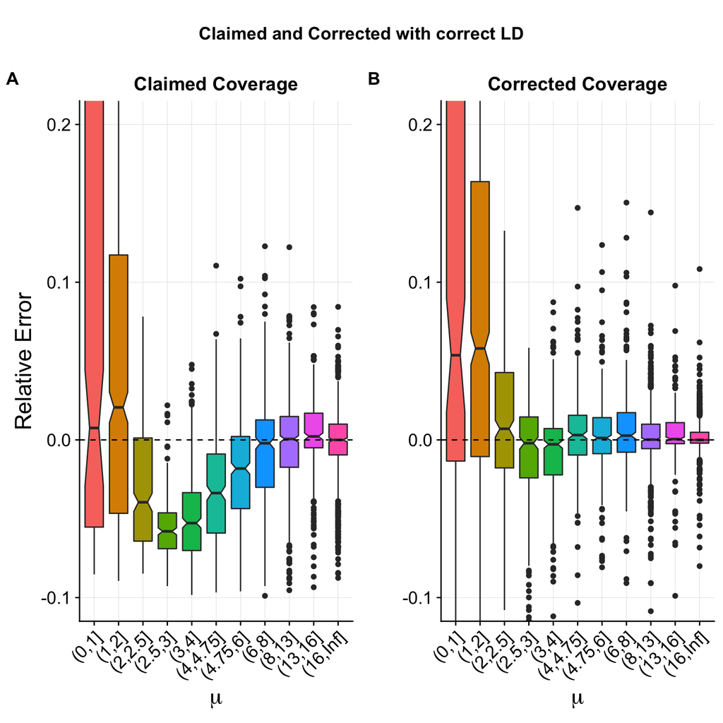

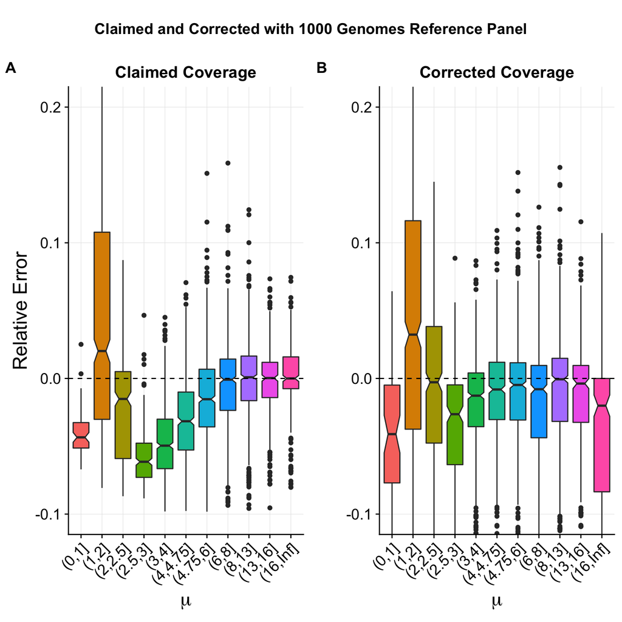

- Note that these results are preliminary and not for the same data. I will rerun this analysis so that the corrected coverage is calculated both using the real data and the reference data in a way that the results can be better compared.

### Update Examples in R Package

- Chris has sent better code that I can use to simulate haplotypes in the function examples (and vignettes?) in my R package.

### Questions for upgrading

- Why is the intercept not written in equation 1? Is the error term really normally distributed?
- $D_{-i}\text{ ind } \beta_i|D_i$ thing?
- Any intuition as to why our estimate for $\mu$ is pretty decent (but not in low $\mu$)?
- JAM, CAVIAR and FINEMAP seem to be concerned with writing the marginal summary statistics in a multivariate formultion but state that individual level data is required for the likelihood and so this needs to be approximated?
- Robs suggestion “examine the effect of sampling from, and re-weighting the prior”. And “pinpointing the cause of the coverage bias and developing additional correction methods”.
- Hi-C stuff, “I aim to specify W within a hierarchical framework that considers multiple baits simultaneoulsy”.
- Difference between CHi-C and HiChIP (something to do with a protein being used?)
- HiChIP is a combination of Hi-C and ChIP-seq. It provides a protein-centric view of genome architecture
- Gnatt chart - “Integrate information on T cell TF binding sites with peaky model”.